# Figure 1D: Transcerebellar Diameter Z-score Trajectory vs Postmenstrual Age

Serial cranial ultrasound TCD referenced to INTERGROWTH-21st (ig_fet / tcdfga); EP / VP / LP

2026-09-03 10:54:17

# Overview

Deck panel **Figure 1D** (row “Serial cranial ultrasound”). The reviewer asked us to compare our preterm infants directly against a **published in-utero fetal normative standard**, like-for-like, so the deviation from the expected fetal trajectory is shown explicitly.

We use the **transcerebellar diameter (TCD)**, measured in the coronal plane on serial cranial ultrasound (`Coronal_Transverse` in the dataset, in mm), and reference each measurement to the **INTERGROWTH-21st** international fetal standard for cerebellar growth (Rodriguez-Sibaja et al., *Ultrasound Obstet Gynecol* 2021;57:614-623; PMID 32196791), via the `gigs` package (`family = "ig_fet"`, `acronym = "tcdfga"`).

Because fetal gestational age and postnatal postmenstrual age (PMA) are the **same clock**, each infant scan at *N* weeks PMA is compared to the fetal norm at GA = *N* weeks. TCD is expressed as a **z-score** and plotted against PMA. The INTERGROWTH standard extends to ~40 weeks, so scans beyond **280 days (40 wk) PMA** have no reference and are dropped (per agreement with C. Cherry). This analysis reproduces `caller.R` (C. Cherry).

```r
library(gigs)
library(readxl)
library(dplyr)
library(tidyr)
library(ggplot2)
library(mgcv)
library(lme4)
library(lmerTest)
library(knitr)
```

# Data + z-score conversion

```r
days_per_month <- 30.44
grp_order <- c("EP", "VP", "LP")
group_cols <- c(EP = "#030403", VP = "#DE1567", LP = "#7BACDC") # ' EP/VP/LP palette

data_file <- find_dataset("Data_S1_InVivo_Cohort.xlsx")

exp <- read_excel(data_file, sheet = "Ultrasound") %>%
 # TCD (transcerebellar diameter, mm) = coronal transverse cerebellar measurement
 mutate(
 TCD = as.numeric(Coronal_Transverse),
 PMA_weeks = as.numeric(PMA_weeks),
 PMA_days = PMA_weeks * 7,
 PMA_months = PMA_days / days_per_month,
 Study_ID = as.character(Study_ID)
 ) %>%
 filter(PMA_days <= 280 & !is.na(TCD)) %>%
 mutate(GA_Group = factor(GA_Group, levels = grp_order))

# Convert each measured TCD to a z-score vs the INTERGROWTH-21st fetal standard
exp$Z.Score <- value2zscore(
 exp$TCD,
 exp$PMA_days,
 family = "ig_fet",
 acronym = "tcdfga"
)

kable(exp %>% count(GA_Group, name = "N_measurements"),
 caption = "TCD measurements per GA group (PMA <= 280 days)")
```

TCD measurements per GA group (PMA <= 280 days)

| GA_Group | N_measurements |
| --- | --- |
| EP | 311 |
| VP | 129 |
| LP | 42 |

# Statistics

```r
# 1. Change in z-score per month (slope; negative = falling further below the norm).
# The slope p-value is scale-invariant, so it is identical whether PMA is in
# weeks or months; annotations report this p-value per group.
growth_rate <- exp %>%
 group_by(GA_Group) %>%
 summarise(
 Z_per_Month = coef(lm(Z.Score ~ PMA_months))[2],
 p = summary(lm(Z.Score ~ PMA_months))$coef[2, 4],
 .groups = "drop"
 )
kable(growth_rate, digits = c(0, 3, 6),
 caption = "Change in TCD z-score per month, by GA group")
```

Change in TCD z-score per month, by GA group

| GA_Group | Z_per_Month | p |
| --- | --- | --- |
| EP | -0.724 | 0.000001 |
| VP | -0.882 | 0.004176 |
| LP | -2.069 | 0.032642 |

```r
# 2. Proportion of measurements below the reference 5th percentile (z < -1.645).
below5 <- exp %>%
 group_by(GA_Group) %>%
 summarise(
 N = n(),
 Below5 = sum(Z.Score < -1.645),
 Percent = 100 * mean(Z.Score < -1.645),
 .groups = "drop"
 )
kable(below5, digits = c(0, 0, 0, 1),
 caption = "Percent of measurements below the reference 5th percentile")
```

Percent of measurements below the reference 5th percentile

| GA_Group | N | Below5 | Percent |
| --- | --- | --- | --- |
| EP | 311 | 181 | 58.2 |
| VP | 129 | 30 | 23.3 |
| LP | 42 | 19 | 45.2 |

```r
# 3. Maximum smoothed z-score deficit (GAM peak deficit), for reference.
pred <- expand_grid(
 PMA_months = seq(98, 280) / days_per_month,
 GA_Group = factor(grp_order, levels = grp_order)
)
gam_fit <- gam(Z.Score ~ GA_Group + s(PMA_months, by = GA_Group),
 data = exp, method = "REML")
pred$Z <- predict(gam_fit, newdata = pred)
max_deficit <- pred %>%
 group_by(GA_Group) %>%
 slice_min(Z, n = 1, with_ties = FALSE) %>%
 transmute(GA_Group,
 Peak_Deficit_Month = PMA_months,
 Peak_Deficit_Z = Z)
kable(max_deficit, digits = c(0, 2, 2),
 caption = "Maximum smoothed z-score deficit (GAM)")
```

Maximum smoothed z-score deficit (GAM)

| GA_Group | Peak_Deficit_Month | Peak_Deficit_Z |
| --- | --- | --- |
| EP | 9.2 | -4.482110 |
| VP | 9.2 | -1.919506 |
| LP | 9.2 | -3.415423 |

```r
# 4. Overall trajectory difference across groups: linear mixed-effects model with
# fixed effects for PMA, group and their interaction, random intercept per infant,
# Type III tests with Satterthwaite degrees of freedom.
fit <- lmer(TCD ~ PMA_months * GA_Group + (1 | Study_ID), data = exp)
anova(fit)
```

```
## Type III Analysis of Variance Table with Satterthwaite's method
##                     Sum Sq Mean Sq NumDF  DenDF F value   Pr(>F)
## PMA_months          515.72  515.72     1 475.52 50.2239 4.98e-12 ***
## GA_Group             61.29   30.65     2 463.25  2.9846  0.05153 .
## PMA_months:GA_Group  55.33   27.66     2 456.58  2.6942  0.06867 .
## ---
## Signif. codes:  0 '***' 0.001 '**' 0.01 '*' 0.05 '.' 0.1 ' ' 1
```

# Figure 1D

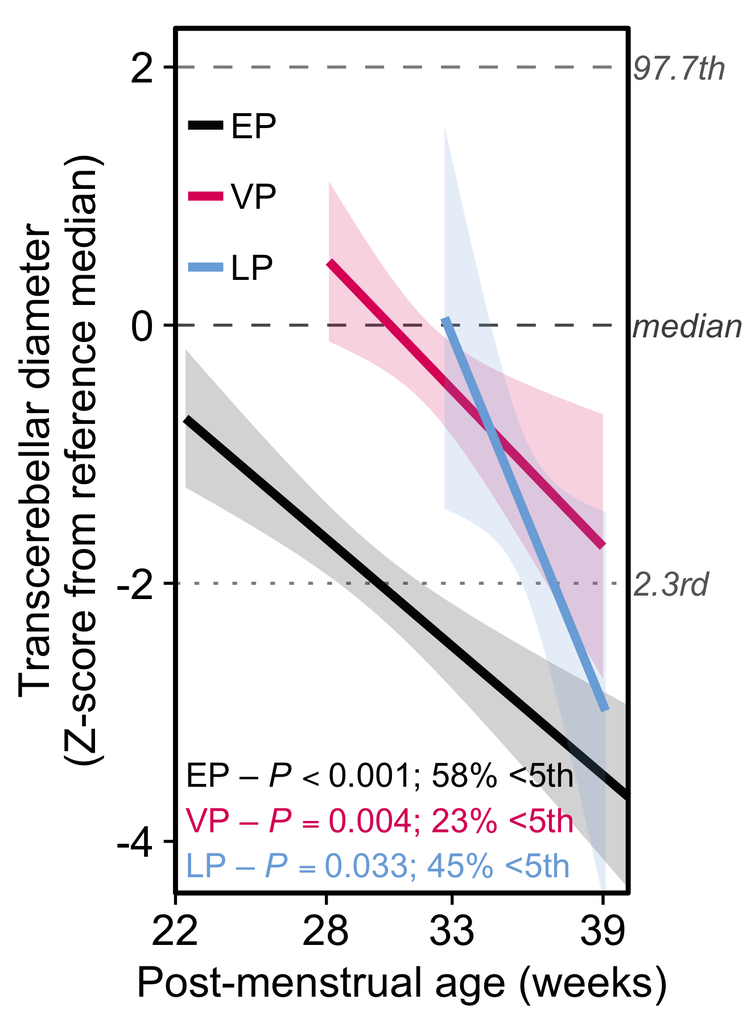

```r
# Annotation strings built from the computed statistics ---------------------
fmt_p <- function(p) ifelse(p < 0.001, "italic(P) < 0.001",
 paste0("italic(P) == '", sprintf("%.3f", p), "'"))
lab <- below5 %>%
 left_join(growth_rate, by = "GA_Group") %>%
 mutate(GA_Group = factor(GA_Group, levels = grp_order)) %>%
 arrange(GA_Group) %>%
 mutate(
 txt = paste0(as.character(GA_Group), "*' – '*", fmt_p(p),
 "*'; '*", sprintf("%.0f", Percent), "*'% <5th'"),
    y   = c(-3.50, -3.85, -4.20)[seq_len(n())]
 )

x_lo <- 22; x_hi <- 40
ref_x <- x_hi + 0.15 # ref-line labels sit just past the right edge

# In-plot legend (top-left), coloured line keys + labels (matches deck panel D)
leg <- data.frame(
 GA_Group = factor(grp_order, levels = grp_order),
 y = c(1.55, 1.00, 0.45)
)

p1d <- ggplot(exp, aes(PMA_weeks, Z.Score, color = GA_Group, fill = GA_Group)) +
 # Reference lines: fetal median and +/- 2 SD (97.7th / 2.3rd centiles)
 geom_hline(yintercept = 2, linetype = "dashed", colour = "grey55", linewidth = 0.3) +
 geom_hline(yintercept = 0, linetype = "dashed", colour = "grey35", linewidth = 0.3) +
 geom_hline(yintercept = -2, linetype = "dotted", colour = "grey55", linewidth = 0.3) +
 # Per-group linear fits vs PMA with 95% CI
 geom_smooth(method = "lm", se = TRUE, linewidth = 0.9, alpha = 0.18) +
 scale_color_manual(values = group_cols) +
 scale_fill_manual(values = group_cols) +
 # Reference-line labels (right side)
 annotate("text", x = ref_x, y = 2, label = "97.7th", hjust = 0, size = 2.5,
 fontface = "italic", colour = "grey40") +
 annotate("text", x = ref_x, y = 0, label = "median", hjust = 0, size = 2.5,
 fontface = "italic", colour = "grey30") +
 annotate("text", x = ref_x, y = -2, label = "2.3rd", hjust = 0, size = 2.5,
 fontface = "italic", colour = "grey40") +
 # Per-group statistic annotations (bottom-left), coloured by group
 geom_text(data = lab, aes(x = x_lo + 0.4, y = y, label = txt, colour = GA_Group),
 parse = TRUE, hjust = 0, size = 2.5, inherit.aes = FALSE,
 show.legend = FALSE) +
 # In-plot legend, top-left: coloured line keys + EP/VP/LP labels
 geom_segment(data = leg, aes(x = x_lo + 0.5, xend = x_lo + 1.9, y = y, yend = y,
 colour = GA_Group),
 linewidth = 0.9, inherit.aes = FALSE, show.legend = FALSE) +
 geom_text(data = leg, aes(x = x_lo + 2.2, y = y, label = as.character(GA_Group)),
 hjust = 0, size = 2.6, colour = "black", inherit.aes = FALSE) +
 scale_x_continuous(breaks = c(22, 28, 33, 39), limits = c(x_lo, x_hi + 3)) +
 scale_y_continuous(breaks = c(2, 0, -2, -4)) +
 coord_cartesian(xlim = c(x_lo, x_hi), ylim = c(-4.4, 2.3),
 expand = FALSE, clip = "off") +
 labs(x = "Post-menstrual age (weeks)",
 y = "Transcerebellar diameter\n(Z-score from reference median)") +
 theme_classic(base_size = 10) +
 theme(
 legend.position = "none",
 axis.text.x = element_text(size = 9),
 axis.text.y = element_text(size = 9),
 axis.title.x = element_text(size = 9),
 axis.title.y = element_text(size = 9),
 axis.line = element_blank(),
 panel.border = element_rect(colour = "black", fill = NA, linewidth = 0.5),
 axis.ticks = element_line(linewidth = 0.3, colour = "black"),
 panel.grid = element_blank(),
 plot.margin = margin(6, 26, 4, 4)
 )

p1d
```

```r
ggsave("Figure_1D_TCD_Zscore_Trajectory.pdf", p1d, width = 2.2, height = 3.0, dpi = 300)
```